# MicroarrayPilot

## T18

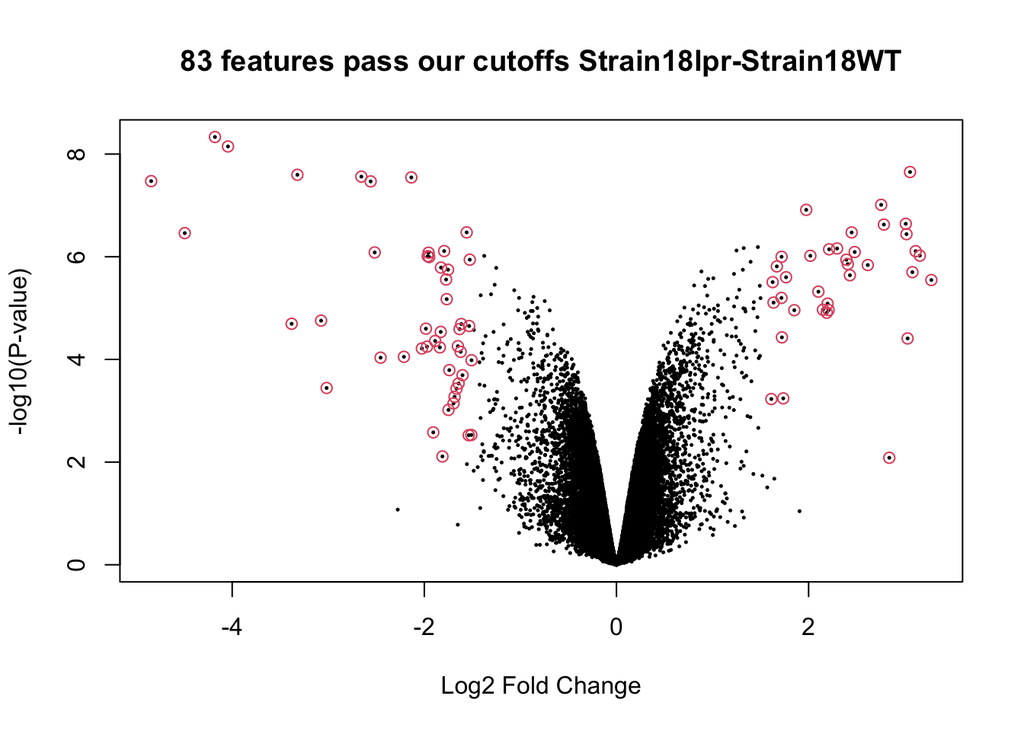

```r
 for (ii in 1 : length(colnames(data.fit.eb18[[1]]))){
    tryCatch({
    # Identify significant genes with log fold change > 1.5 and < 0.1 significance
    signif_genes <- topTable(data.fit.eb18,coef=ii,number=Inf,p.value = 0.1,lfc=1.5)
    # Create a title for the plot
    title <- paste(sprintf("%d features pass our cutoffs", nrow(signif_genes)), colnames(data.fit.eb18[[1]])[ii])
    # Generate the volcano plot using the `volcanoplot()` function
    volcanoplot(data.fit.eb18, coef=ii, main=title)
    # Add the significant genes to the plot using the `points()` function
    points(signif_genes[['logFC']], -log10(signif_genes[['P.Value']]), col=2)

  }, error=function(e){cat("ERROR :",conditionMessage(e), "\n")})
  }
```

# Heat Map

## T24

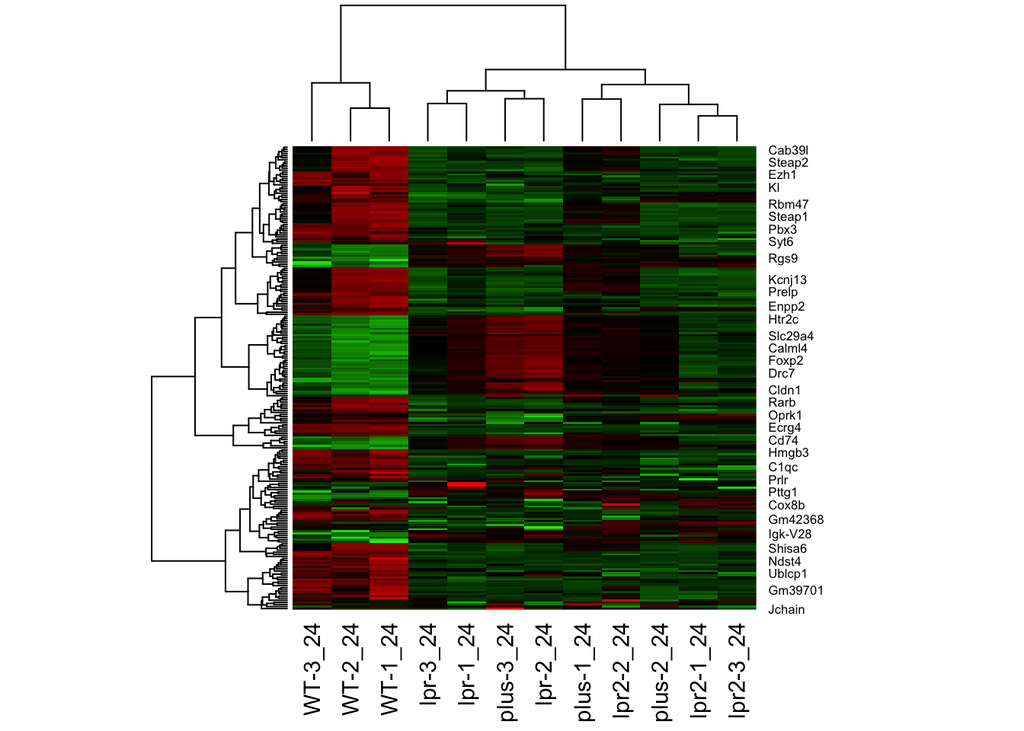

## T18

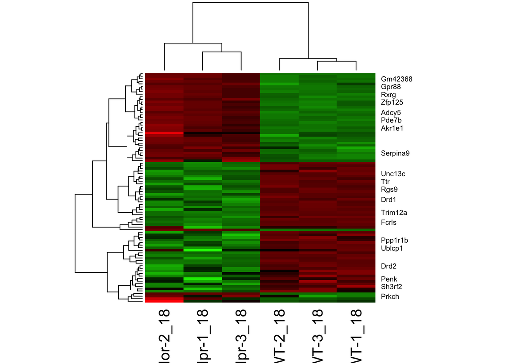

# Biological interpretation of differential expression

## T24

### topGO

topGO is an R package used to perform Gene Ontology (GO) enrichment analysis. GO enrichment analysis can be used to identify which GO terms are significantly overrepresented in a set of genes of interest. The output from the topGO analysis has been saved in a PDFs and is available in the data folder. Rectangle color represents the relative significant, ranging from dark red (most significant) to bright yellow (least significant).

### Reactome

Reactome is a database of biological pathways, which provides detailed information about the molecular events that take place in cells. We use the ‘ReactomePA’ package for performing enrichment analysis on sets of genes or proteins to identify pathways that are significantly enriched in the data. The output from the Reactome analysis has been saved in a PDFs and is available in the data folder.

### GO

The gene ontology annotation takes the GO number for each gene and creates a list. The list is then put into a loop where the loop cycles through each number and Ontology (BP,MF,CC) and grabs the summary from the website. It is slow so run it with caution.

### Ncbi Summary

The Following code runs through the genes extracted and grabs the NCBI summary/abstract from the NCBI website using the Entrez ID as reference. (Please look at the RMD for full code).

## T18

### topGO

topGO is an R package used to perform Gene Ontology (GO) enrichment analysis. GO enrichment analysis can be used to identify which GO terms are significantly overrepresented in a set of genes of interest. The output from the topGO analysis has been saved in a PDFs and is available in the data folder. Rectangle color represents the relative significant, ranging from dark red (most significant) to bright yellow (least significant).

### Reactome

Reactome is a database of biological pathways, which provides detailed information about the molecular events that take place in cells. We use the ‘ReactomePA’ package for performing enrichment analysis on sets of genes or proteins to identify pathways that are significantly enriched in the data. The output from the Reactome analysis has been saved in a PDFs and is available in the data folder.

### GO

The gene ontology annotation takes the GO number for each gene and creates a list. The list is then put into a loop where the loop cycles through each number and Ontology (BP,MF,CC) and grabs the summary from the website. It is slow so run it with caution.

### Ncbi Summary

The Following code runs through the genes extracted and grabs the NCBI summary/abstract from the NCBI website using the Entrez ID as reference. (Please look at the RMD for full code).

# Exporting the Data

Here we export the data as an Excel file for ease of access for further investigations.